# Name:

# Instructions

- Add your name above
- Fill in the empty chunks with your code.
- Do not add any code chunks in your final submission besides the ones already here.
- Use **no** additional modules.
- You must submit your answers on canvas in **HTML** format !!!

```python
import numpy as np
import pandas as pd

from scipy.optimize import linprog
import matplotlib.pyplot as plt
```

# Problem 1: Multi-Year Investment Strategy

A hedge fund has \$150,000 to invest over a four-year horizon. There are four investment options available:

- **Annuity:** The fund can invest the same amount at the beginning of years 1, 2, 3, and 4, and receive 140\% return on the total capital at the end of year 4. This option has restriction, if you invest any amount in year 1, you must invest the same amount in every year after that!
- **Savings Account:** The fund can invest any amount at the beginning of each year to receive the capital plus 5\% return at the end of each year. They can also borrow up to \$25,000 at the beginning of each year, to be repaid with 5\% interest at the end of the year.
- **Tech Startup Investment:** At the start of the year 2, an opportunity to invest in a promising tech startup becomes available. The fund can invest up to \$75,000 in this option. If they choose to invest, they will receive the invested capital plus 150\% return at the end of the fourth year. (Notice, here you get not 150\% in total but invested capital PLUS 150\% return).
- **Real Estate Fund:** This option becomes available from year 3. The fund can invest any amount at the start of 3rd or 4th year, and they will receive 110\% of the invested capital at the end of year 4.

The hedge fund aims to maximize its total payout at the end of the four-year period.

### Question 1.1: Formulate this as a linear programming problem mathematically (write objective function and constraints in the next cell (below) which is in a markdown mode).

**The objective functions:**

1. Fund invests $4x_1$ in annuity to get $1.40\cdot 4x_1$
2. At the begining of year 4 fund has $x_5$ on the bank account and will get 5\% return on it, $1.05x_5$
3. Fund can invest $x_6$ in the startup at the start of year 2 to get $(1+1.50)x_6$ at the end of year 4.
4. Invest $x_7$ in year 3 and $x_8$ in year 4 and get $1.1\cdot x_7+1.1\cdot x_8$

So in total, fund will have: $$1.40\cdot 4x_1 + 1.05x_5 + 2.50x_6 + 1.1x_7 + 1.1x_8$$

**Constraints:**

We can rewrite all of this in linear programming framework:

\begin{split} \begin{aligned} \max_{x} \ & 1.40\cdot 4x_1 + 1.05x_5 + 2.50x_6 + 1.1x_7 + 1.1x_8 \\ \mbox{subject to } \ & x_1 + x_2 = 150,000\\ & x_1 - 1.05 x_2 + x_3 + x_6 = 0\\ & x_1 - 1.05 x_3 + x_4 + x_7 = 0\\ & x_1 - 1.05 x_4 + x_5 + x_8 = 0\\ & x_2 \ge -25,000\\ & x_3 \ge -25,000\\ & x_4 \ge -25,000\\ & x_5 \ge -25,000\\ & x_6 \le 75,000\\ & x_j \ge 0, \quad j = 1,6,7,8\\ & x_j \ \text{unrestricted from above}, \quad j = 1,2,3,4,5,7,8\\ \end{aligned} \end{split}

### Question 1.2: implement and solve this problem computationally.

(you might need to modify tollerance level for linprog in order to get message: 'Optimization terminated successfully.', search how to do it.)

```python
# Objective function parameters
c_ex2 = np.array([1.40*4, 0, 0, 0, 1.05, 2.50, 1.1, 1.1])

# equality constraints
A_ex2 = np.array([[1,  1,  0,  0,  0, 0, 0, 0],
                  [1, -1.05, 1, 0, 0, 1, 0, 0],
                  [1, 0, -1.05, 1, 0, 0, 1, 0],
                  [1, 0, 0, -1.05, 1, 0, 0, 1]])
b_ex2 = np.array([150000, 0, 0, 0])

# Bounds on decision variables
bounds_ex2 = [(  0,    None),
              (-25000, None),
              (-25000, None),
              (-25000, None),
              (-25000, None),
              (  0,   75000),
              (0, None),
              (0, None)]

# Solve the problem
res_ex2 = linprog(-c_ex2, A_eq=A_ex2, b_eq=b_ex2, bounds=bounds_ex2, options = {"tol": 1e-14})

res_ex2
```

```
     con: array([-3.49245965e-10,  4.94765118e-10,  7.73070497e-12,  5.45696821e-12])
     fun: -311908.04356022156
 message: 'Optimization terminated successfully.'
     nit: 12
   slack: array([], dtype=float64)
  status: 0
 success: True
       x: array([ 2.69032221e+04,  1.23096778e+05,  2.73483948e+04,  1.81259244e+03,
       -2.50000000e+04,  7.50000000e+04,  3.14018905e-12,  3.54407266e-14])
```

### Question 1.3: perform a sensitivity analysis on the interest rates. How would the optimal strategy change if the real estate return increases from 110\% to 180\%? (Explain)

```python
# Objective function parameters
c_ex2 = np.array([1.40*4, 0, 0, 0, 1.05, 2.50, 1.8, 1.8])

# equality constraints
A_ex2 = np.array([[1,  1,  0,  0,  0, 0, 0, 0],
                  [1, -1.05, 1, 0, 0, 1, 0, 0],
                  [1, 0, -1.05, 1, 0, 0, 1, 0],
                  [1, 0, 0, -1.05, 1, 0, 0, 1]])
b_ex2 = np.array([150000, 0, 0, 0])

# Bounds on decision variables
bounds_ex2 = [(  0,    None),
              (-25000, None),
              (-25000, None),
              (-25000, None),
              (-25000, None),
              (  0,   75000),
              (0, None),
              (0, None)]

# Solve the problem
res_ex2 = linprog(-c_ex2, A_eq=A_ex2, b_eq=b_ex2, bounds=bounds_ex2, options = {"tol": 1e-14})

res_ex2
```

```
     con: array([-1.27183739e-08,  2.29629222e-08, -4.07453626e-09, -8.58562998e-10])
     fun: -369971.25
 message: 'Optimization terminated successfully.'
     nit: 12
   slack: array([], dtype=float64)
  status: 0
 success: True
       x: array([ 1.36214560e-13,  1.50000000e+05,  8.25000000e+04,  8.66250000e+04,
       -2.50000000e+04,  7.50000000e+04,  5.41368636e-11,  1.15956250e+05])
```

In this case, since real estate is now more attractive compared to annuities, most of the money previously allocated to annuities will move to real estate.

# Problem 2: Modified Schelling's Segregation Model

**Set up:**

**Preferences:**

Preferences depend on 10 nearest neighbors (in term of euclidian distance). An agent is happy if at least 4 of the 10 nearest neighbors are the same type and unhappy otherwise.

**Actions:**

Agent can move or stay based on happiness.

**Timeline:**

1. Agents are randomly allocated in a unit squre, in other words, their location is randomly drawn from bivariate uniform distribution from (0, 1).
2. In every period, each agent simultaniously decided to move or stay:
   - Stay if happy
   - Move if unhappy and draw new location from bivariate uniform distribution from (0, 1)

Game continues until eveyrone is happy!

### Question 2.1: initializes all agents with random positions on the unit square and show graphically.

```python
# draw randomly all locations
agents = pd.DataFrame(np.random.uniform(0, 1, size = (1000, 2)), columns=['x', 'y'])


# assign type where 0 is oragne, 1 is green and 2 is blue
agents['type']=0
agents.loc[300:500, 'type']=1
agents.loc[500:, 'type']=2

agents.head()
```

|  | x | y | type |
| --- | --- | --- | --- |
| 0 | 0.331544 | 0.850296 | 0 |
| 1 | 0.170087 | 0.904473 | 0 |
| 2 | 0.037560 | 0.434690 | 0 |
| 3 | 0.361917 | 0.858273 | 0 |
| 4 | 0.275393 | 0.276624 | 0 |

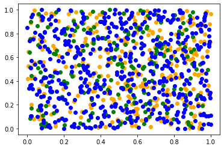

```python
# we use scatterplot to show them on unit square

plt.scatter(agents[agents['type']==0]['x'], agents[agents['type']==0]['y'], color = 'orange')
plt.scatter(agents[agents['type']==1]['x'], agents[agents['type']==1]['y'], color = 'green')
plt.scatter(agents[agents['type']==2]['x'], agents[agents['type']==2]['y'], color = 'blue')


plt.show()
```

### Question 2.2: Implement the logic where each agent checks whether they are happy or unhappy and moves if necessary. Run the simulation iteratively until all agents are happy. Track the number of iterations it takes for the system to reach a stable state where no agent wants to move.

```python
# Write a function which takes, locations, number of neighbours that need to be considerd and happyness condition
# as an argument, prints at each iteration number of agents who moved and outputs updated data where everyone is
# happy

def scheling(data_agents, neigbours, happy_condition):

    # first we need to make a copy of the original data here in order to keep the original and reuse it below in
    # question 2.4

    data = data_agents.copy()


    # Let's assign initial value to unhappy = 1
    unhappy = 1


    # In order to count how many iterations it takes to converge (nobody to be willing to move) we also define iteration
    # as zero and increae this nunmber by one each time while loop happens
    iteration = 0

    # as we said, in order to get the while loop started, the initial condition should be true. By initial assignment
    # unhappy=1 so  it is > 0:

    while unhappy>0:
        # create a placeholder where we store all the agents that moved.
        moved=[]

        # to keep the original data unafected until all the agents decide to move or not in each iteration
        # we make a copy of it
        data_temp=data.copy()

        # now we loop over each agent to see if they want to move or not
        for agent in data.index.tolist():

            # their moving decision depends on number of similar types aroud the agent. We calculate distance manually
            # one step at a time, but you can put all in one line

            # first calculate elementwise difference between the given agents lication and everyone esle
            diff = data_temp[['x', 'y']]-data_temp.loc[agent, ['x', 'y']]

            # square each coordinate difference
            sq_diff = diff**2

            # sum squares of differences
            sum_sq_diff = sq_diff.sum(axis=1)

            # take  a square toot from the sum
            sqrt_sum_sq_diff = sum_sq_diff**0.5

            # in the temporary dataframe add a column which containes distance between a given agent and everyone else
            # includine the agent hersels (the distance between agent and herself should be zero)
            data_temp['sqrt_sum_sq_diff'] = sqrt_sum_sq_diff


            # The agent will be unhappy if less then 4 are the same type, so the agent is unhappy if the number is < happy_condition.

            if sum(data_temp.sort_values(by='sqrt_sum_sq_diff')['type'][1:neigbours+1]==data_temp.loc[agent, 'type'])<happy_condition:
                # if the condition is met, the agent is unhappy and moves.
                # We will append list "moved" where we store all the agents who moved in a given iteration
                moved.append(agent)

                # Since the agent moves we will update her location in the original(!!!) data not in the copied version!
                data.loc[agent, ['x', 'y']]=np.random.uniform(0, 1, size = (1, 2))[0]

        # After we check every agent, we find how many people where unhappy and if number is more than 0 while loop continues
        unhappy=len(moved)

        # At this point the iteration is done and we increase it by one to keep the record of how many iterations we are doing
        iteration += 1

        # to keep infromation coming at every iteration we print out what is happening in our code
        print('On iteration: '+str(iteration)+': '+str(len(moved))+' agets moved')

    return data
```

```python
# call function with respective inputs and save updated data as agents_converged:

agents_converged = scheling(agents, 10, 4)
```

```
On iteration: 1: 462 agets moved
On iteration: 2: 381 agets moved
On iteration: 3: 306 agets moved
On iteration: 4: 245 agets moved
On iteration: 5: 204 agets moved
On iteration: 6: 155 agets moved
On iteration: 7: 126 agets moved
On iteration: 8: 105 agets moved
On iteration: 9: 86 agets moved
On iteration: 10: 67 agets moved
On iteration: 11: 57 agets moved
On iteration: 12: 48 agets moved
On iteration: 13: 39 agets moved
On iteration: 14: 31 agets moved
On iteration: 15: 25 agets moved
On iteration: 16: 18 agets moved
On iteration: 17: 14 agets moved
On iteration: 18: 11 agets moved
On iteration: 19: 5 agets moved
On iteration: 20: 5 agets moved
On iteration: 21: 4 agets moved
On iteration: 22: 2 agets moved
On iteration: 23: 1 agets moved
On iteration: 24: 1 agets moved
On iteration: 25: 1 agets moved
On iteration: 26: 1 agets moved
On iteration: 27: 1 agets moved
On iteration: 28: 0 agets moved
```

### Question 2.3: Plot the result

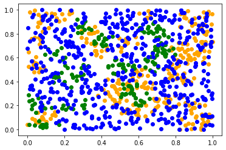

```python
# plot here

plt.scatter(agents_converged[agents_converged['type']==0]['x'], agents_converged[agents_converged['type']==0]['y'], color = 'orange')
plt.scatter(agents_converged[agents_converged['type']==1]['x'], agents_converged[agents_converged['type']==1]['y'], color = 'green')
plt.scatter(agents_converged[agents_converged['type']==2]['x'], agents_converged[agents_converged['type']==2]['y'], color = 'blue')


plt.show()
```

### Question 2.4: re-sumulate your results for the case of 15 neigbours. That is, agent looks at 15 neigbours and makes moving decisions based on 4 of closest 15 neighbours.

```python
# call function with new parameters and save updated data as agents_converged_new:

agents_converged_new = scheling(agents, 15, 4)
```

```
On iteration: 1: 223 agets moved
On iteration: 2: 154 agets moved
On iteration: 3: 120 agets moved
On iteration: 4: 90 agets moved
On iteration: 5: 67 agets moved
On iteration: 6: 53 agets moved
On iteration: 7: 43 agets moved
On iteration: 8: 32 agets moved
On iteration: 9: 24 agets moved
On iteration: 10: 15 agets moved
On iteration: 11: 5 agets moved
On iteration: 12: 3 agets moved
On iteration: 13: 3 agets moved
On iteration: 14: 2 agets moved
On iteration: 15: 0 agets moved
```

### Question 2.5: explain what was the impact of moving from 10 to 15 neighbors case?

Your answer in this markdown cell:

Convergence happened much faster because the happiness condition is less restrictive, as we only need at least 4 out of 15 to be the same type, instead of 4 out of 10.